# Assignment #2 - Introduction to Data Analysis

Sheetal Gangakhedkar

May 3, 2017

## Questions

### 1. Create two matrices from the given set of numbers X1={2,3,7,1,6,2,3,5,1} and x2={3,2,9,0,7,8,5,8,2}

```r
# create matrix X1 and X2 with given data
X1 = matrix(c(2,3,7,1,6,2,3,5,1), nrow=3, ncol=3, byrow=FALSE)
X2 = matrix(c(3,2,9,0,7,8,5,8,2), nrow=3, ncol=3, byrow=FALSE)
```

### 2. Find the matrix product

```r
# multiply matrix X1 with X2
prodX1X2 = X1 %*% X2
prodX1X2
```

```
##      [,1] [,2] [,3]
## [1,]   35   31   24
## [2,]   66   82   73
## [3,]   34   22   53
```

### 3. Find the inverse of the matrix and prove that it is correct.

```r
# solve to get the inverse of matrix
iX1 = solve(X1)
class(iX1) == "matrix"
```

```
## [1] TRUE
```

```r
iX1
```

```
##             [,1]        [,2]        [,3]
## [1,]  0.04761905 -0.05952381  0.15476190
## [2,] -0.38095238  0.22619048  0.01190476
## [3,]  0.42857143 -0.03571429 -0.10714286
```

```r
# prove that X1 multiplied with its inverse returns an identity matrix
identityX1 = iX1 %*% X1
identityX1
```

```
##              [,1]         [,2]          [,3]
## [1,] 1.000000e+00 1.110223e-16 -2.775558e-17
## [2,] 1.387779e-17 1.000000e+00  2.550044e-16
## [3,] 0.000000e+00 0.000000e+00  1.000000e+00
```

```r
isSymmetric(identityX1)
```

```
## [1] TRUE
```

```r
# solve to get the inverse of matrix
iX2 = solve(X2)
class(iX2) == "matrix"
```

```
## [1] TRUE
```

```r
iX2
```

```
##            [,1]        [,2]        [,3]
## [1,]  0.1298701 -0.10389610  0.09090909
## [2,] -0.1766234  0.10129870  0.03636364
## [3,]  0.1220779  0.06233766 -0.05454545
```

```r
# prove that X1 multiplied with its inverse returns an identity matrix
identityX2 = iX2 %*% X2
identityX2
```

```
##               [,1]          [,2]          [,3]
## [1,]  1.000000e+00 -1.110223e-16 -8.326673e-17
## [2,]  1.665335e-16  1.000000e+00  0.000000e+00
## [3,] -5.551115e-17 -5.551115e-17  1.000000e+00
```

```r
isSymmetric(identityX2)
```

```
## [1] TRUE
```

### 4. Load the Animals data set from the “MASS” package

```r
data(package="MASS", "Animals")
head(Animals)
```

```
##                     body brain
## Mountain beaver     1.35   8.1
## Cow               465.00 423.0
## Grey wolf          36.33 119.5
## Goat               27.66 115.0
## Guinea pig          1.04   5.5
## Dipliodocus     11700.00  50.0
```

### 5. Find the correlation coefficient of brain and body in this data set and comment on the relation between them

```r
# convert animal body weight into same units 'grams' as the brain weight, and then get correlation coeff
# help(package="MASS", "Animals")
cor(Animals$body*1000, Animals$brain, method="pearson")
```

```
## [1] -0.005341163
```

It appears the Animal body weight and brain weight have a very low negative relationship and almost no correlation, using the default “pearson” method.

### 6. Load USArrests data set. Comment on the distribution of the variables. Is there any relation between UrbanPop and three crimes.

```r
data(USArrests)
head(USArrests)
```

```
##            Murder Assault UrbanPop Rape
## Alabama      13.2     236       58 21.2
## Alaska       10.0     263       48 44.5
## Arizona       8.1     294       80 31.0
## Arkansas      8.8     190       50 19.5
## California    9.0     276       91 40.6
## Colorado      7.9     204       78 38.7
```

```r
dim(USArrests)
```

```
## [1] 50  4
```

#### Understanding the distribution of variables in the USArrests data set.***

```r
summary(USArrests)
```

```
##      Murder          Assault         UrbanPop          Rape
##  Min.   : 0.800   Min.   : 45.0   Min.   :32.00   Min.   : 7.30
##  1st Qu.: 4.075   1st Qu.:109.0   1st Qu.:54.50   1st Qu.:15.07
##  Median : 7.250   Median :159.0   Median :66.00   Median :20.10
##  Mean   : 7.788   Mean   :170.8   Mean   :65.54   Mean   :21.23
##  3rd Qu.:11.250   3rd Qu.:249.0   3rd Qu.:77.75   3rd Qu.:26.18
##  Max.   :17.400   Max.   :337.0   Max.   :91.00   Max.   :46.00
```

We see that Murder rate is centered at 7.25, spread is 16.6 and interquartile range is 7.175

We see that Assault rate is centered at 159.0, spread is 292.0 and interquartile range is 140.0

We see that Urban Population rate is centered at 66.0, spread is 59 and interquartile range is 23.25

We see that Rape rate is centered at 20.10, spread is 38.7 and interquartile range is 11.11

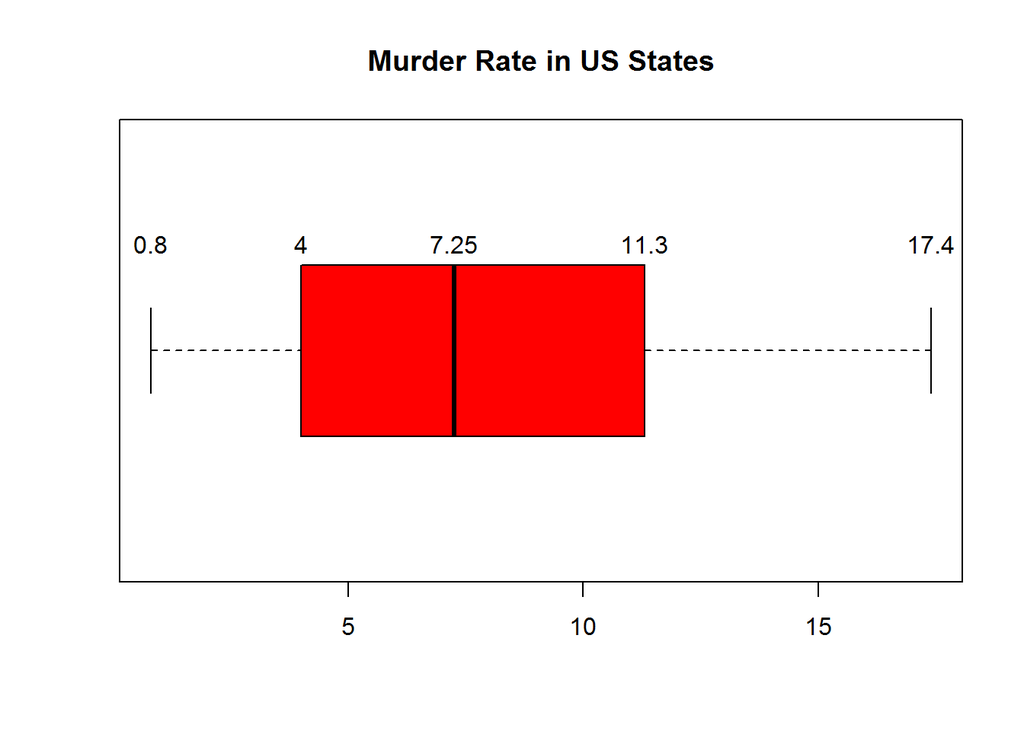

```r
boxplot(USArrests$Murder, horizontal=TRUE, col=2, main="Murder Rate in US States")
text(x=fivenum(USArrests$Murder), labels =fivenum(USArrests$Murder), y=1.25)
```

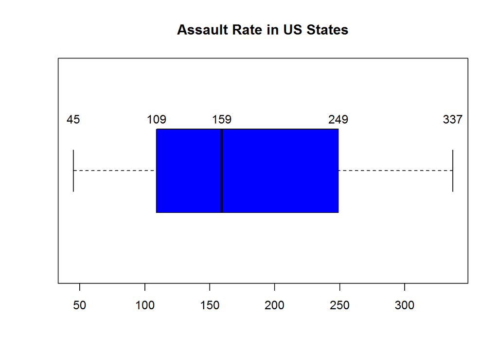

```r
boxplot(USArrests$Assault, horizontal=TRUE, col=4, main="Assault Rate in US States")
text(x=fivenum(USArrests$Assault), labels =fivenum(USArrests$Assault), y=1.25)
```

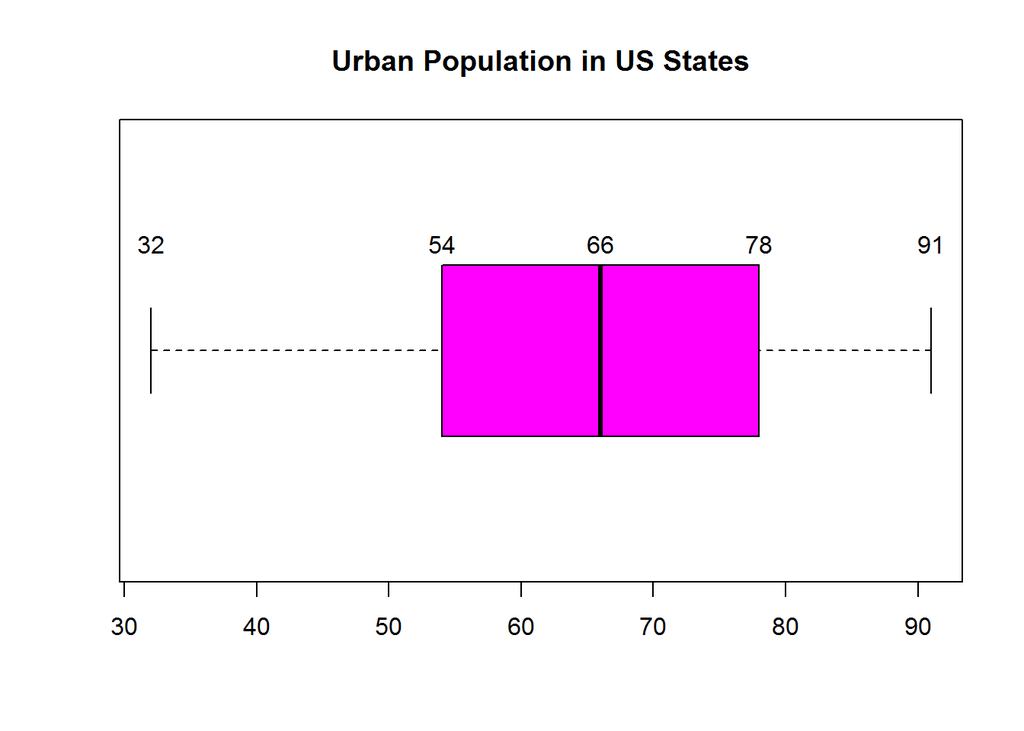

```r
boxplot(USArrests$UrbanPop, horizontal=TRUE, col=6, main="Urban Population in US States")
text(x=fivenum(USArrests$UrbanPop), labels =fivenum(USArrests$UrbanPop), y=1.25)
```

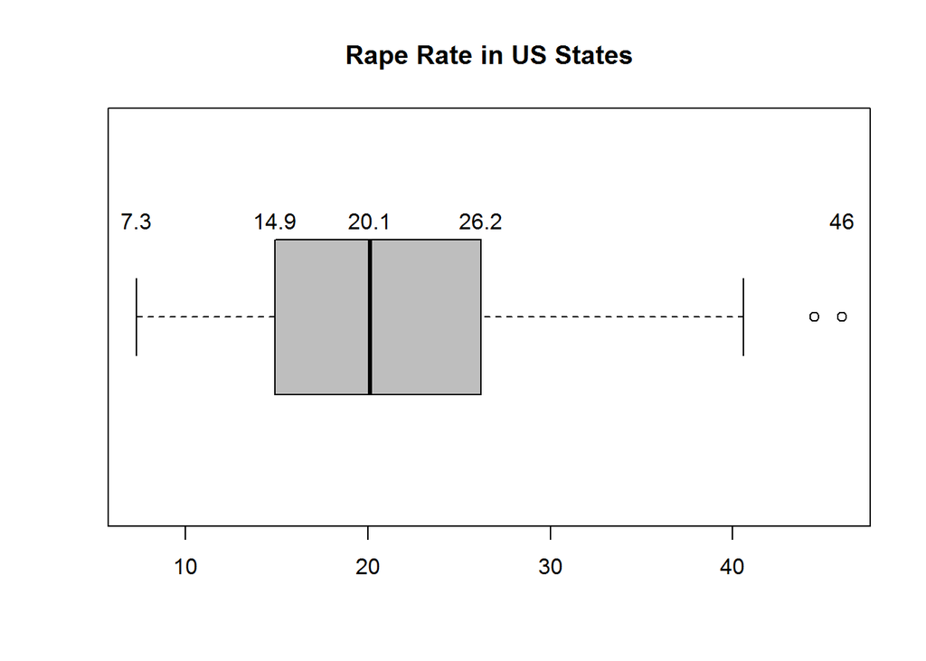

```r
boxplot(USArrests$Rape, horizontal=TRUE, col=8, main="Rape Rate in US States")
text(x=fivenum(USArrests$Rape), labels=fivenum(USArrests$Rape), y=1.25)
```

#### Standard deviation of USArrests data for Murder, Assault, Urban Population and Rape rates data

```r
sapply(USArrests[,1:4], sd)
```

```
##    Murder   Assault  UrbanPop      Rape
##  4.355510 83.337661 14.474763  9.366385
```

#### Distribution plot of USArrests data set

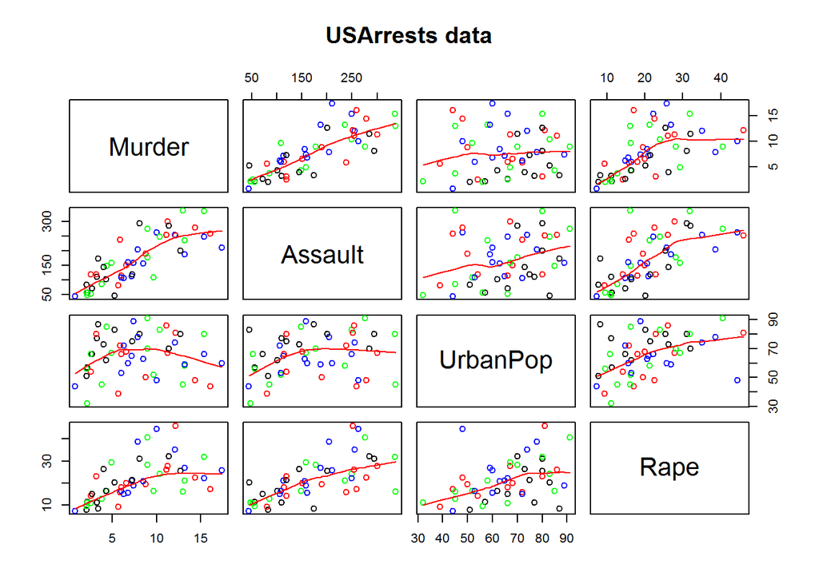

```r
pairs(USArrests, panel = panel.smooth, main = "USArrests data", col=c("green","blue","black","red"))
```

#### Correlation of data columns in USArrests data set

```r
cor(USArrests[,1:4])
```

```
##              Murder   Assault   UrbanPop      Rape
## Murder   1.00000000 0.8018733 0.06957262 0.5635788
## Assault  0.80187331 1.0000000 0.25887170 0.6652412
## UrbanPop 0.06957262 0.2588717 1.00000000 0.4113412
## Rape     0.56357883 0.6652412 0.41134124 1.0000000
```

Correlation data shows that Murder and Assault rates are positively and highly correlated, followed medium level correlation between Assault and Rape rates. The least related is the Urban Polulation and Murder rates data.

```r
cor(USArrests$UrbanPop, USArrests$Murder)
```

```
## [1] 0.06957262
```

```r
cor(USArrests$UrbanPop, USArrests$Assault)
```

```
## [1] 0.2588717
```

```r
cor(USArrests$UrbanPop, USArrests$Rape)
```

```
## [1] 0.4113412
```

Urban Population and Murder rates have no correlation with a positive but very weak or no relationship. Urban Population and Assault rates have a low correlation with a positive relationship. Urban Population and Rape rates have a medium correlation with a positive relationship.

#### Histogram Distribution of variables in the USArrests data set.

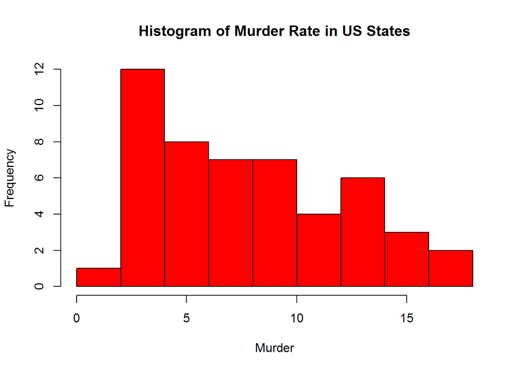

```r
# histogram of Murder arrests per 100k popluation in 50 US states
hist(USArrests[,1], col=2, main="Histogram of Murder Rate in US States", xlab=colnames(USArrests)[1])
```

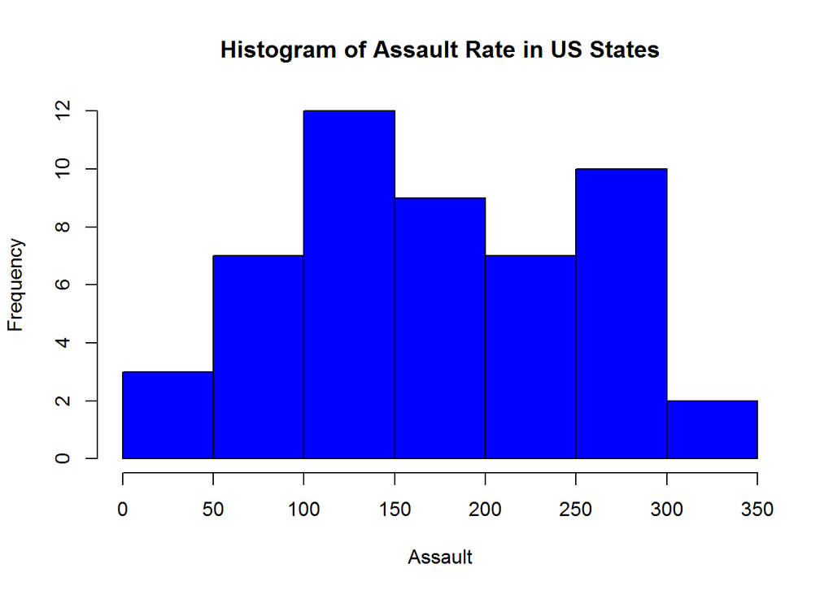

```r
# histogram of Assault arrests per 100k popluation in 50 US states
hist(USArrests[,2], col=4, main="Histogram of Assault Rate in US States", xlab=colnames(USArrests)[2])
```

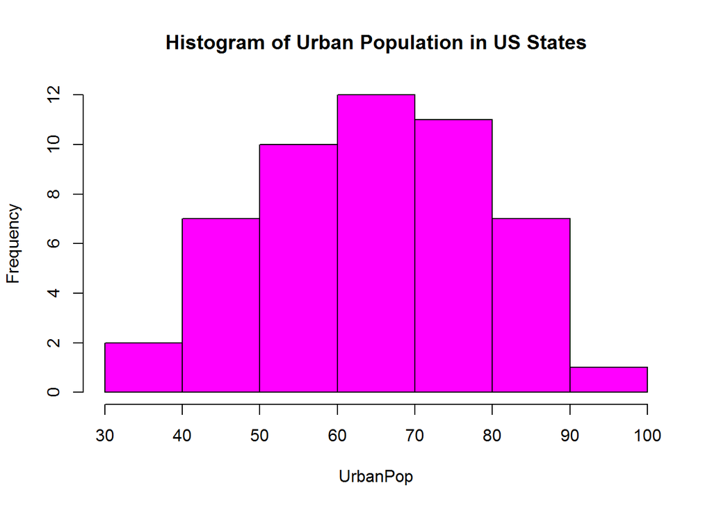

```r
# histogram of Urban population per 100k popluation in 50 US states
hist(USArrests[,3], col=6, main="Histogram of Urban Population in US States", xlab=colnames(USArrests)[3])
```

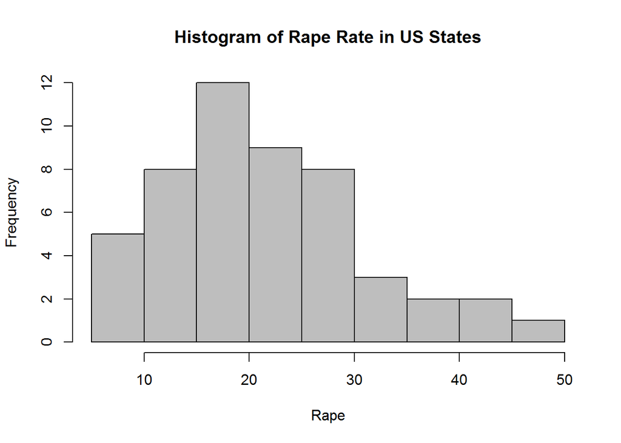

```r
# histogram of Rape arrests per 100k popluation in 50 US states
hist(USArrests[,4], col=8, main="Histogram of Rape Rate in US States", xlab=colnames(USArrests)[4])
```

### 7. Which states has most and least assault, murder, and rape arrests.

```r
# states with least Murder arrests
USArrests[which(USArrests$Murder==min(USArrests$Murder)),]
```

```
##              Murder Assault UrbanPop Rape
## North Dakota    0.8      45       44  7.3
```

```r
row.names(USArrests[which(USArrests$Murder==min(USArrests$Murder)),])
```

```
## [1] "North Dakota"
```

```r
# states with least Assault arrests
USArrests[which(USArrests$Assault==min(USArrests$Assault)),]
```

```
##              Murder Assault UrbanPop Rape
## North Dakota    0.8      45       44  7.3
```

```r
row.names(USArrests[which(USArrests$Assault==min(USArrests$Assault)),])
```

```
## [1] "North Dakota"
```

```r
# states with least Rape arrests
USArrests[which(USArrests$Rape==min(USArrests$Rape)),]
```

```
##              Murder Assault UrbanPop Rape
## North Dakota    0.8      45       44  7.3
```

```r
row.names(USArrests[which(USArrests$Rape==min(USArrests$Rape)),])
```

```
## [1] "North Dakota"
```

```r
# states with most Murder arrests
USArrests[which(USArrests$Murder==max(USArrests$Murder)),]
```

```
##         Murder Assault UrbanPop Rape
## Georgia   17.4     211       60 25.8
```

```r
row.names(USArrests[which(USArrests$Murder==max(USArrests$Murder)),])
```

```
## [1] "Georgia"
```

```r
# states with most Assault arrests
USArrests[which(USArrests$Assault==max(USArrests$Assault)),]
```

```
##                Murder Assault UrbanPop Rape
## North Carolina     13     337       45 16.1
```

```r
row.names(USArrests[which(USArrests$Assault==max(USArrests$Assault)),])
```

```
## [1] "North Carolina"
```

```r
# states with most Rape arrests
USArrests[which(USArrests$Rape==max(USArrests$Rape)),]
```

```
##        Murder Assault UrbanPop Rape
## Nevada   12.2     252       81   46
```

```r
row.names(USArrests[which(USArrests$Rape==max(USArrests$Rape)),])
```

```
## [1] "Nevada"
```

### 8. List the states which have assault arrests more than median of the country.

```r
median(USArrests$Assault)
```

```
## [1] 159
```

```r
USArrests[which(USArrests$Assault>median(USArrests$Assault)),]
```

```
##                Murder Assault UrbanPop Rape
## Alabama          13.2     236       58 21.2
## Alaska           10.0     263       48 44.5
## Arizona           8.1     294       80 31.0
## Arkansas          8.8     190       50 19.5
## California        9.0     276       91 40.6
## Colorado          7.9     204       78 38.7
## Delaware          5.9     238       72 15.8
## Florida          15.4     335       80 31.9
## Georgia          17.4     211       60 25.8
## Illinois         10.4     249       83 24.0
## Louisiana        15.4     249       66 22.2
## Maryland         11.3     300       67 27.8
## Michigan         12.1     255       74 35.1
## Mississippi      16.1     259       44 17.1
## Missouri          9.0     178       70 28.2
## Nevada           12.2     252       81 46.0
## New Mexico       11.4     285       70 32.1
## New York         11.1     254       86 26.1
## North Carolina   13.0     337       45 16.1
## Rhode Island      3.4     174       87  8.3
## South Carolina   14.4     279       48 22.5
## Tennessee        13.2     188       59 26.9
## Texas            12.7     201       80 25.5
## Wyoming           6.8     161       60 15.6
```

```r
row.names(USArrests[which(USArrests$Assault>median(USArrests$Assault)),])
```

```
##  [1] "Alabama"        "Alaska"         "Arizona"        "Arkansas"
##  [5] "California"     "Colorado"       "Delaware"       "Florida"
##  [9] "Georgia"        "Illinois"       "Louisiana"      "Maryland"
## [13] "Michigan"       "Mississippi"    "Missouri"       "Nevada"
## [17] "New Mexico"     "New York"       "North Carolina" "Rhode Island"
## [21] "South Carolina" "Tennessee"      "Texas"          "Wyoming"
```

### 9. Which states are in the bottom 25% of murder

Bottom 25% means in this case, states having murder rates above 75% or 3rd Quartile murder rate

```r
# 3rd Quantile for murder rates
quartile3 = quantile(USArrests$Murder)[4]
quartile3
```

```
##   75%
## 11.25
```

```r
USArrests[which(USArrests$Murder>=quartile3),]
```

```
##                Murder Assault UrbanPop Rape
## Alabama          13.2     236       58 21.2
## Florida          15.4     335       80 31.9
## Georgia          17.4     211       60 25.8
## Louisiana        15.4     249       66 22.2
## Maryland         11.3     300       67 27.8
## Michigan         12.1     255       74 35.1
## Mississippi      16.1     259       44 17.1
## Nevada           12.2     252       81 46.0
## New Mexico       11.4     285       70 32.1
## North Carolina   13.0     337       45 16.1
## South Carolina   14.4     279       48 22.5
## Tennessee        13.2     188       59 26.9
## Texas            12.7     201       80 25.5
```

```r
row.names(USArrests[which(USArrests$Murder>=quartile3),])
```

```
##  [1] "Alabama"        "Florida"        "Georgia"        "Louisiana"
##  [5] "Maryland"       "Michigan"       "Mississippi"    "Nevada"
##  [9] "New Mexico"     "North Carolina" "South Carolina" "Tennessee"
## [13] "Texas"
```

### 10. Which states are in the top 25% of the murder.

Top 25% means in this case, states having murder rates below 25% or 1st Quartile murder rate

```r
# 1st Quantile for murder rates
quartile1 = quantile(USArrests$Murder)[2]
quartile1
```

```
##   25%
## 4.075
```

```r
USArrests[which(USArrests$Murder<=quartile1),]
```

```
##               Murder Assault UrbanPop Rape
## Connecticut      3.3     110       77 11.1
## Idaho            2.6     120       54 14.2
## Iowa             2.2      56       57 11.3
## Maine            2.1      83       51  7.8
## Minnesota        2.7      72       66 14.9
## New Hampshire    2.1      57       56  9.5
## North Dakota     0.8      45       44  7.3
## Rhode Island     3.4     174       87  8.3
## South Dakota     3.8      86       45 12.8
## Utah             3.2     120       80 22.9
## Vermont          2.2      48       32 11.2
## Washington       4.0     145       73 26.2
## Wisconsin        2.6      53       66 10.8
```

```r
row.names(USArrests[which(USArrests$Murder<=quartile1),])
```

```
##  [1] "Connecticut"   "Idaho"         "Iowa"          "Maine"
##  [5] "Minnesota"     "New Hampshire" "North Dakota"  "Rhode Island"
##  [9] "South Dakota"  "Utah"          "Vermont"       "Washington"
## [13] "Wisconsin"
```